# Clustering tutorial, with solutions

## k-means clustering

Kmeans in R is fairly simple:

```r
mygroups<-kmeans( data, k) #where data is a matrix and k is the number of clusters you want
```

The output of this has several interesting things: in particular:

```r
mygroups$cluster # - a label for each of the rows in your matrix corresponding to
# what group it is assigned to (1-k)
mygroups$centers # a summary of the center of each group
```

The cancer-samples.txt file has two columns. These are gene expression data from two genes, in a large number of cancer samples (rows). The question is how many groups that are present in the data.

in this set, we have the advantage that we only have two genes, which means we can plot them vs each other in an x-y plot. We will do this to look at the resulting clusters. But, if we have more genes, the plotting like this would be difficult, as we have too many dimensions.

First, read in the file, plot gene1 vs gene2 as a scatterplot. It is pretty obvious that there are some sort of grouping(s) in this data. Use this to suggest a couple of different numbers for ‘k’.

SOLUTION

Read in the file plot expressio of gene 1 and 2:

```r
cancer.data<-read_tsv("cancer_samples.txt")
cancer.data
```

```
## # A tibble: 94 x 2
##    Gene1.exp Gene2.exp
##        <dbl>     <dbl>
##  1      8.20    0.781
##  2      9.16    9.54
##  3      9.33   10.5
##  4      9.50    0.968
##  5      9.32    1.66
##  6     19.7    17.8
##  7     14.4     8.57
##  8     10.7    -0.0736
##  9     10.9     1.53
## 10      9.58   11.0
## # ... with 84 more rows
```

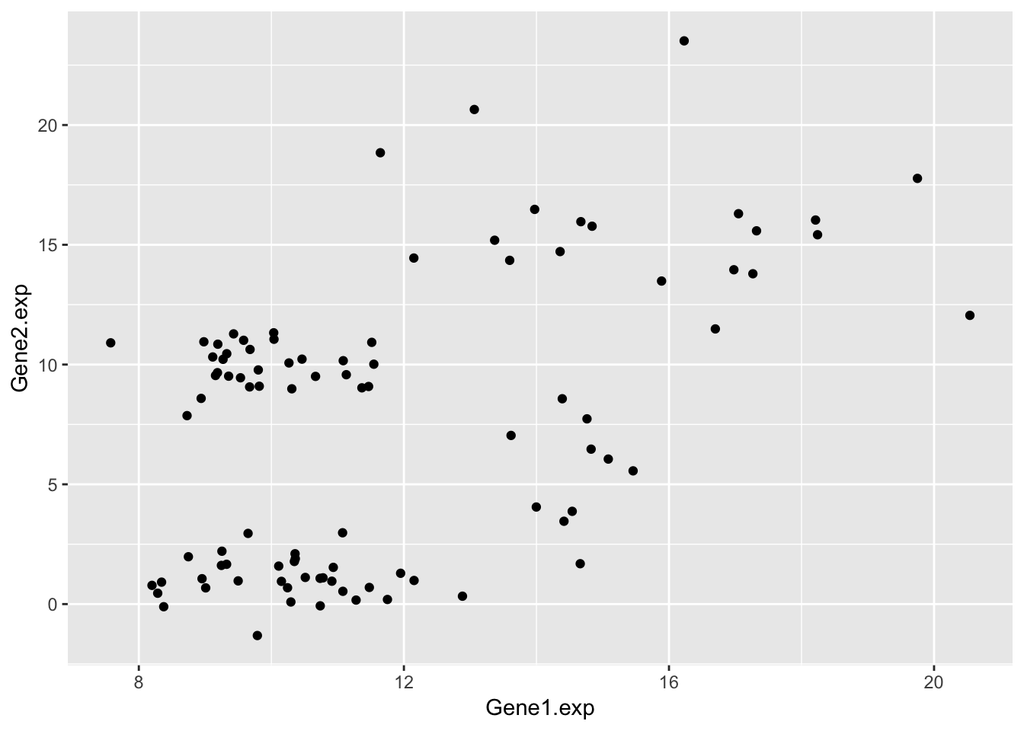

```r
ggplot(cancer.data, aes(x=Gene1.exp, y=Gene2.exp))+geom_point()
```

Second, make a matrix based on the tibble you read in. Use this matrix as input to k.means(), and try to visualize the groups in the plot you have. Hint 1: try to find out what my.groups in mygroups contains. Hint 2: mygroups$cluster. Select some different ‘k’

SOLUTION:

```r
cancer.data.m<-as.matrix(cancer.data)
head(cancer.data.m)
```

```
##      Gene1.exp  Gene2.exp
## [1,]  8.198884  0.7811669
## [2,]  9.157390  9.5427918
## [3,]  9.327060 10.4520095
## [4,]  9.499086  0.9683603
## [5,]  9.324620  1.6612560
## [6,] 19.749264 17.7723632
```

```r
my.groups.3<- kmeans(cancer.data.m, 2)
my.groups.3
```

```
## K-means clustering with 2 clusters of sizes 40, 54
##
## Cluster means:
##   Gene1.exp Gene2.exp
## 1  10.87408  1.511482
## 2  12.40132 11.939887
##
## Clustering vector:
##  [1] 1 2 2 1 1 2 2 1 1 2 1 2 2 1 1 1 2 2 2 2 2 2 1 2 2 2 2 1 1 2 2 1 2 1 1
## [36] 2 1 1 2 1 1 2 1 1 2 1 2 1 1 2 2 2 1 2 2 2 1 1 1 1 2 2 2 2 1 2 2 1 2 2
## [71] 1 2 2 1 2 2 2 1 2 2 2 2 2 1 1 1 2 2 2 1 2 1 1 2
##
## Within cluster sum of squares by cluster:
## [1]  235.8087 1245.3345
##  (between_SS / total_SS =  63.3 %)
##
## Available components:
##
## [1] "cluster"      "centers"      "totss"        "withinss"
## [5] "tot.withinss" "betweenss"    "size"         "iter"
## [9] "ifault"
```

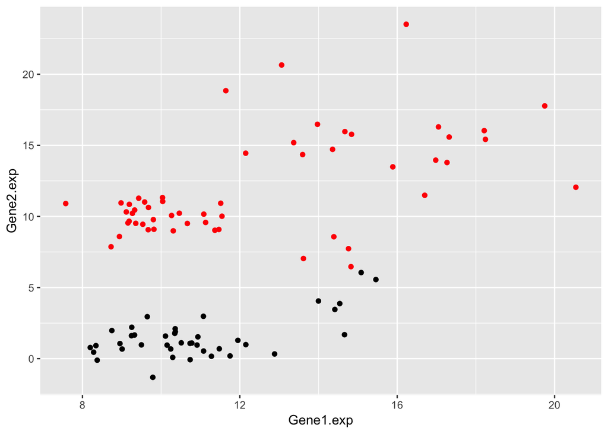

```r
ggplot(cancer.data, aes(x=Gene1.exp, y=Gene2.exp))+
  geom_point(col=as.factor(my.groups.3$cluster))
```

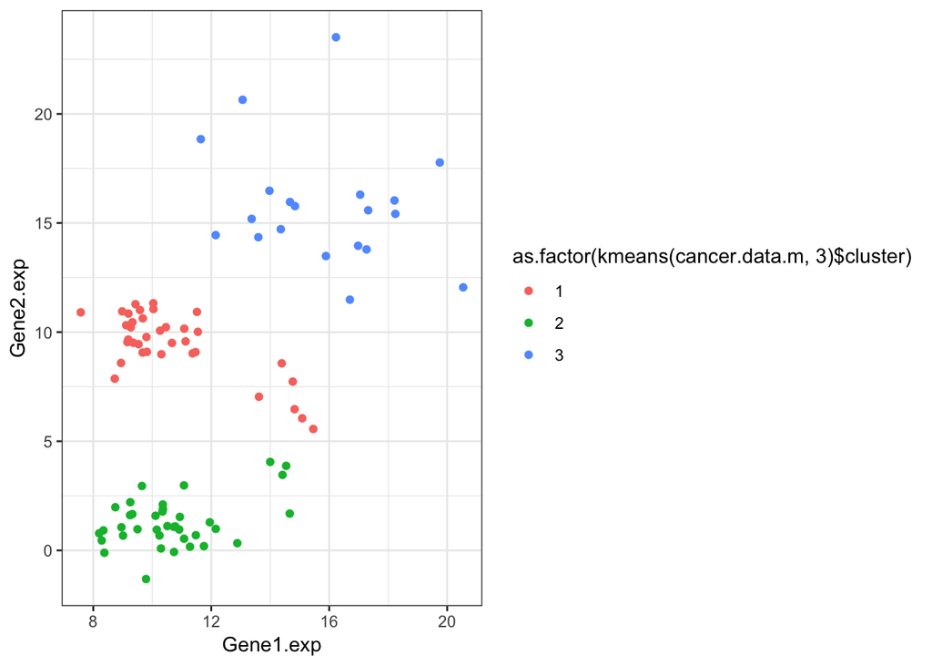

```r
# or, a bit faster
ggplot(cancer.data, aes(x=Gene1.exp, y=Gene2.exp))+
  geom_point(aes
             (col=as.factor(
               kmeans(cancer.data.m, 3)$cluster)))+
  theme_bw()
```

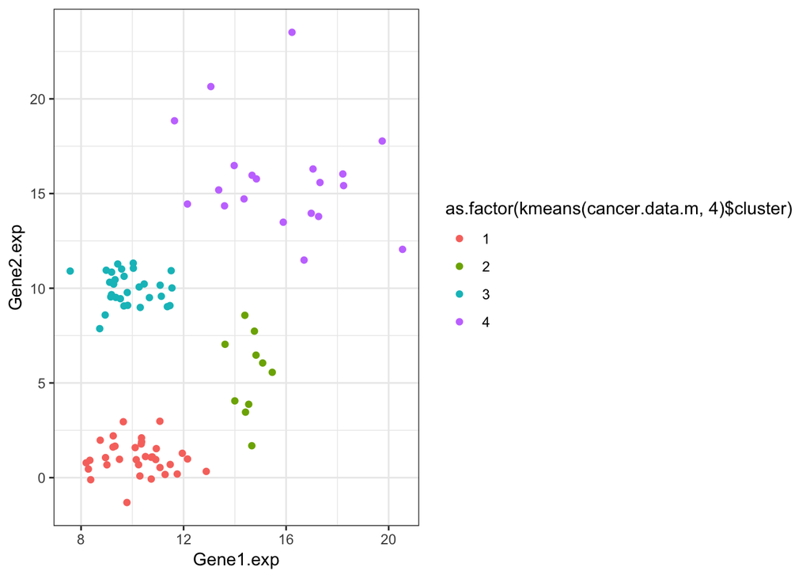

```r
ggplot(cancer.data, aes(x=Gene1.exp, y=Gene2.exp))+
  geom_point(aes
      (col=as.factor(kmeans(cancer.data.m, 4)$cluster)))+
  theme_bw()
```

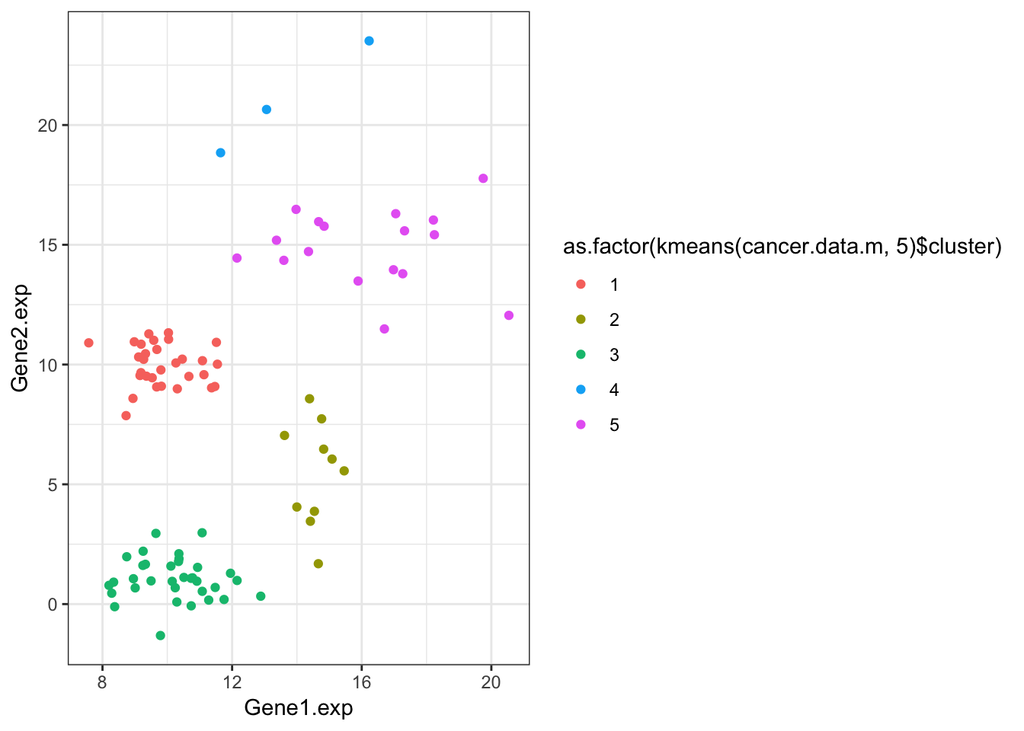

```r
ggplot(cancer.data, aes(x=Gene1.exp, y=Gene2.exp))+
  geom_point(aes
  (col=as.factor(kmeans(cancer.data.m, 5)$cluster)))+
  theme_bw()
```

Challenge: only if you feel you have the time. Can you remake the plot below? It shows both the cluster labels of each point and the center of ach cluster (as a grey large dot), following a k means where k=4.

Hint: each geom can have its own data=…

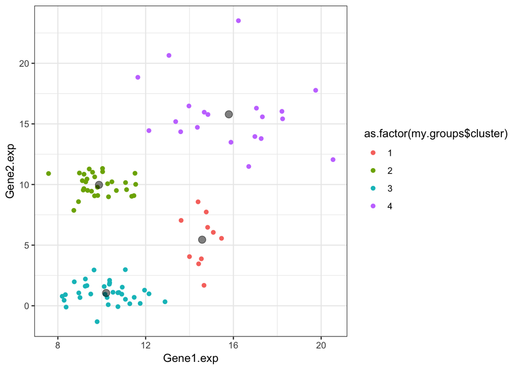

SOLUTION:

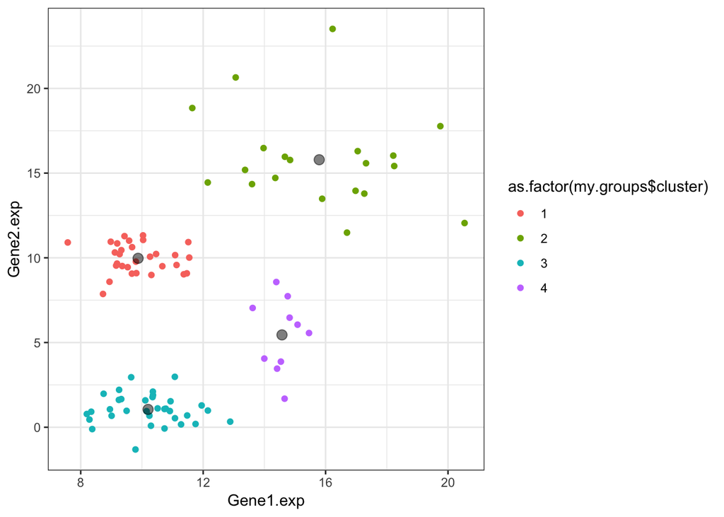

```r
my.groups<- kmeans(cancer.data.m, 4)
my_centers<-as.tibble(my.groups$centers)

ggplot(cancer.data, aes(x=Gene1.exp, y=Gene2.exp))+
  geom_point(aes(col=as.factor
                 (my.groups$cluster)))+theme_bw()+
      geom_point(data=my_centers,
                 aes(x=Gene1.exp, y=Gene2.exp),
                 size=3, alpha=0.5)
```

# II: Hierarchical clustering

Use the same matrix as above, but calculate the distance between all rows using Euclidian distance, then do a hierarchical clustering and plot the tree. Look at the tree - what is it that we are looking at? What is on Y and X, what are the leaves?

Functions to look up: dist(), hclust()

If you have time: Say that we want three or four groups based on the tree. The cutree() function outputs group membership for all rows, much like the clusters in k means. You can also use the rect.hclust() function to draw rectangles on the tree, corresponing to groups. Use the cutree() function for this. Are these the same groups as corresponding k-means clustering? Hint: table().

SOLUTION

Plotting the tree using base R, then selecting k=4 and plotting those:

```r
my.dist<-dist(cancer.data.m)
my.tree<-hclust(my.dist)
plot(my.tree)
split.tree<-cutree(my.tree, k=4)
split.tree
```

```
##  [1] 1 2 2 1 1 3 1 1 1 2 1 4 2 1 1 1 2 3 2 2 2 2 1 2 3 3 2 1 1 4 1 1 1 1 1
## [36] 4 1 1 2 1 1 3 1 1 4 1 2 1 1 2 4 1 1 2 3 2 1 1 1 1 2 2 4 2 1 2 2 1 3 4
## [71] 1 2 2 1 3 4 3 1 2 2 4 4 2 1 1 1 2 3 2 1 2 1 1 2
```

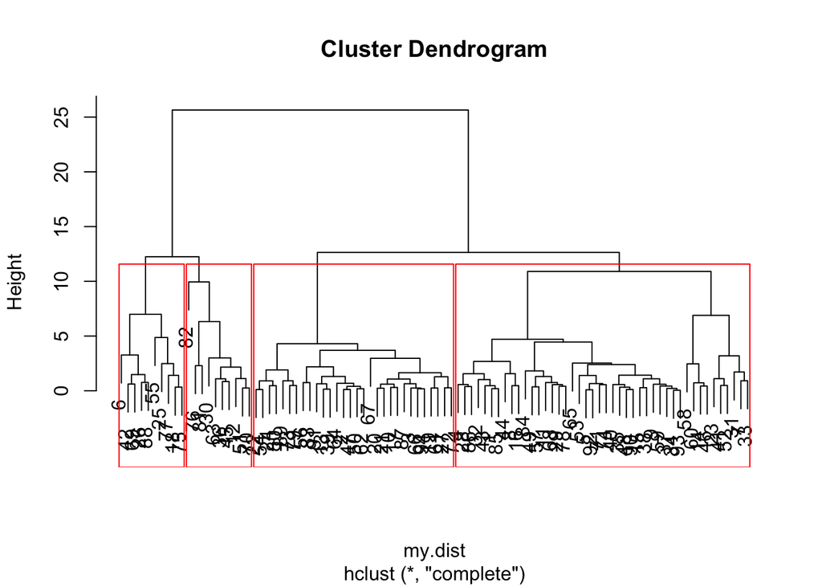

```r
rect.hclust(my.tree, k=4, border="red")
```

–

Are those the same groups as from k-means where =4? there are more fancy ways of doing this, but I simply tabulated them with table(). This is better than a direct comparison of eg cluster 1 to cluster 1 from both groups, becasue they might find the same group but name them differently.

```r
my.tibble<-tibble(km=my.groups$cluster,
                  hierarch=split.tree)
# not strictly  necessary to make a tibble, but feels cleaner.
table(my.tibble)
```

```
##    hierarch
## km   1  2  3  4
##   1  0 30  0  0
##   2  0  0 10 10
##   3 34  0  0  0
##   4 10  0  0  0
```

–

# III Heatmaps

Let us first make a very simple heatmap based on the cancer data above. This will not utilize the full power of heatmaps since we only have two genes. Install the ‘pheatmap’ package and try this:

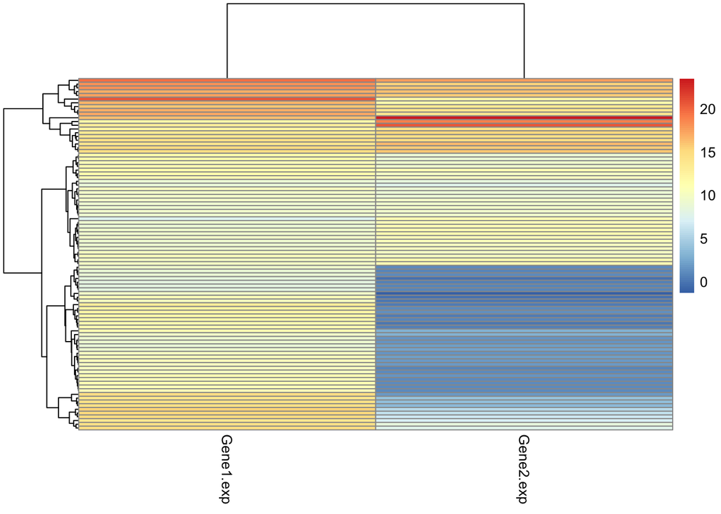

```r
library(pheatmap)
#base heatap
pheatmap(cancer.data.m)
```

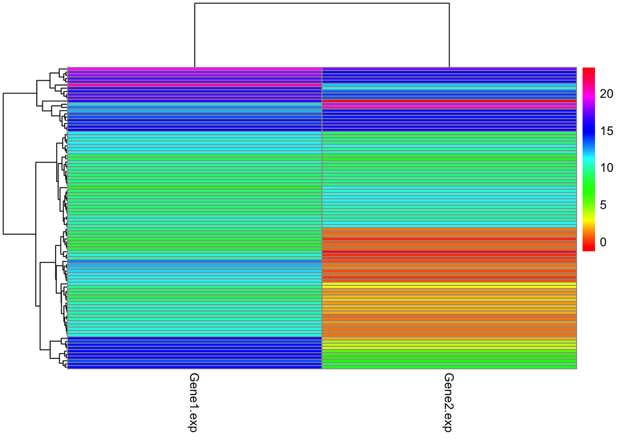

```r
# base heatnap with different color scales
pheatmap(cancer.data.m,  color=rainbow(100)) # horrible
```

```r
library(viridis) # requires installation of viridis package
```

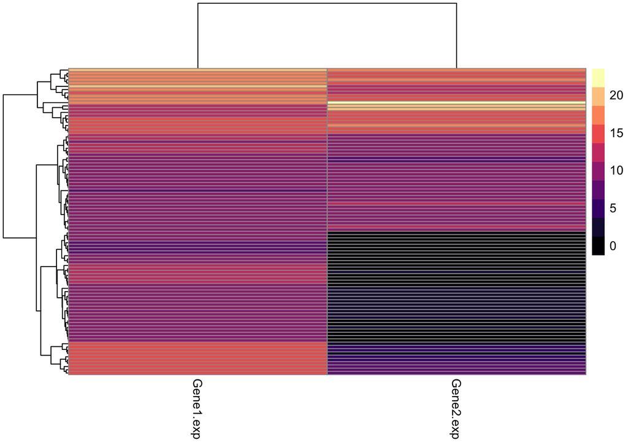

```r
pheatmap(cancer.data.m,  color=magma(10)) # quite nice
```

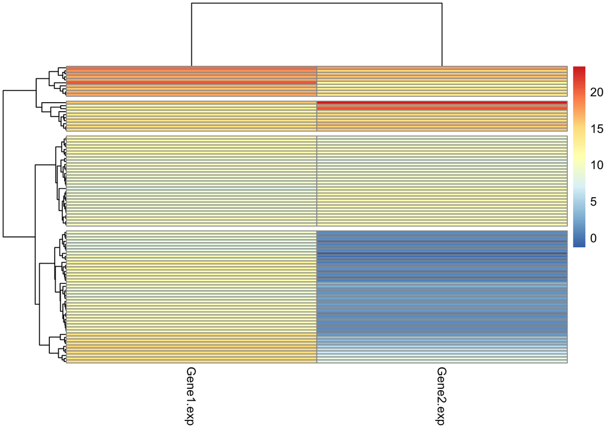

```r
# heatmap is split by using cutree on the row tree (k=4)
pheatmap(cancer.data.m, cutree_rows = 4)
```

[figure not shown]

```r
# comparing this splitup with the
#k means groups that we made before
# some necessary ground work here -
#1) making a data frme for "annotation":
#in this case k means groups
temp<-data.frame(kmeans=my.groups$cluster)

# 2) the matrix neeeds row names so that it
#can be matched with the data frame above.
row.names(cancer.data.m)<-1:94

# and drawing the heat map
pheatmap(cancer.data.m, cutree_rows = 4,
         annotation_row=as.factor(temp))
```

```r
# the idea of using extra rows and
#columns like this to show other
# data and how it is "explained"
#by the clustering is very nice.
# We typically think of these data as "co-variates"
```

What is it that we see? Are the same groups as we saw in the plots in a) and b) visible?

SOLUTION

–

The real power of heatmaps is to visualize data with many columns and rows at once. To do this, we need more genes than in our cancer example.

The more_patients.txt file has exactly this: rows are genes, columns are patients being exposed to a drug. The first column show gene names, which should not be part of the actual heatmap data - but it should be used as row labels in the matrix so that they get uased as labels in the reulting heatmap. We are told that some of the patients seem to be responding to the drug.

What patients are these and what genes are these? Are most of those gene down-or up-regulated?

If you have time (this is a bit harder): In the file annotation.txt, there is annotation category for each of the genes (gene names in col 1, annotation category in col2). Can you use the annotation categories as an extra columns in the heatmap (like we did for k means in the small heat map above) to make the data even more understandable? Tip: pheatmap annotation_row wants a data frame, it cannot deal with tibbles.

SOLUTION

```r
library(pheatmap)
library(viridis)
more.patients<-read_tsv("more_patients.txt")
more.patients
```

```
## # A tibble: 50 x 10
##    GeneID    pat1   pat2   pat3    pat4   pat5   pat6   pat7  pat8  pat9
##    <chr>    <dbl>  <dbl>  <dbl>   <dbl>  <dbl>  <dbl>  <dbl> <dbl> <dbl>
##  1 SCN1A  -2.68    6.09   1.30   5.96    3.08   0.243  1.45   3.25  2.08
##  2 CDK6    0.0809 -1.28   5.56  -2.53    1.52   4.35   5.12   6.92  4.63
##  3 TRPA1  -5.76   -3.77   0.470  7.94    1.48  -0.512 -1.73   1.58  1.20
##  4 TPMT    0.412  -1.43  -6.71   1.23   -0.216 -5.79  -8.22  -8.87 -8.19
##  5 E2F1    1.37    2.35   1.04  -5.73   -3.47   1.55   1.80   2.60  2.16
##  6 TYMP   NA      -2.45   4.74  10.1     0.119  4.05   5.40   3.00  4.94
##  7 GATA2  -0.478   2.45  -1.63   7.04    2.66  -2.06   0.124 -1.56 -1.68
##  8 XPC    -3.30   12.5    1.59   0.0102 -4.75   3.24   2.87   3.06  1.89
##  9 TNNT1   0.0150  0.717  2.06  -5.50   -2.14   2.18   2.55   1.84  2.25
## 10 CDKN1B -4.30   -4.20   1.54  -3.65    1.14   2.12   1.25   3.34  2.34
## # ... with 40 more rows
```

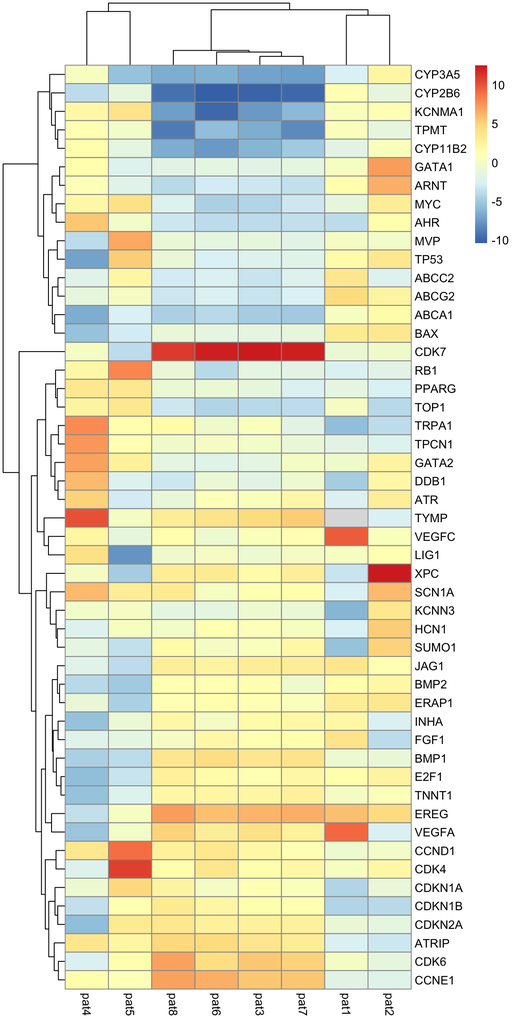

```r
more.patients.m <-as.matrix(more.patients[2:9])
row.names(more.patients.m)<- more.patients$GeneID
pheatmap((more.patients.m), show_rownames = TRUE)
```

Again, we have the patients as columns, now ordered after patient similarity (in gene expression), and genes ordered after their similarity, also from gene expression. The tree on the left shows gene expression similarity, the one on top is patient similarity. Here, red is high expression and blue is low.

What about adding these extra data as a co-variate (gene classes)?

```r
## challenge 2
annotation<-as.data.frame(read_tsv("gene_annotation.txt"))
```

```r
# becasue for historical reasons,
#pheatmap annotation_row likes data frames and not tibbles...
head(annotation)
```

```
##   GeneID       GeneClass
## 1  SCN1A     ion channel
## 2   CDK6      cell cycle
## 3  TRPA1     Ion channel
## 4   TPMT Drug metabolism
## 5   E2F1     Cell growth
## 6   TYMP     Cell growth
```

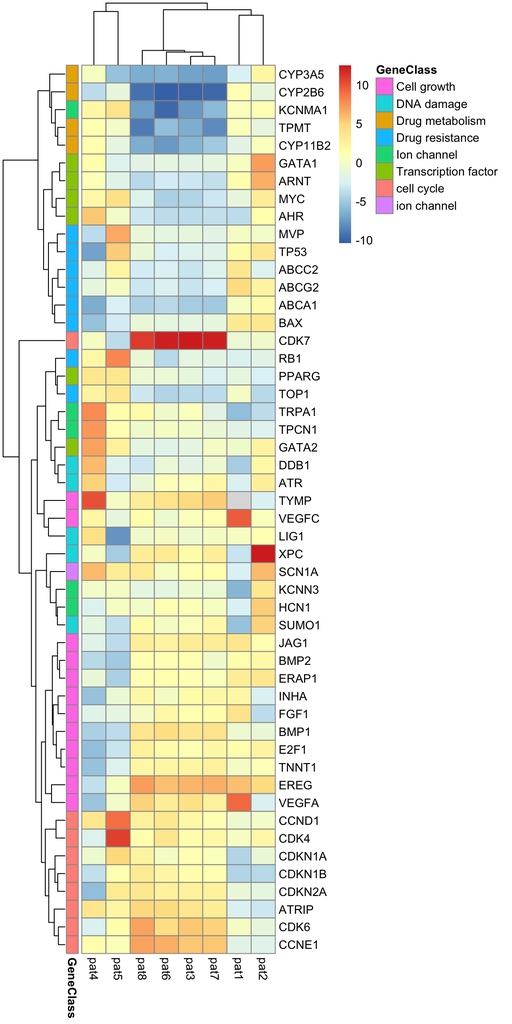

```r
# we pick only the second row, which is the gene
#categories, and use the gene IDs as now names
annotation2<-annotation[2]
row.names(annotation2)<-annotation$GeneID
# plot the heatmap
pheatmap((more.patients.m), annotation_row=annotation2)
```

This adds a new columns to the left, corresponing to the “gene class” annotation. What we can see is that the genes that are close to one another also share annotation categories, so there appears to be some biology going on here! In particluar, there are big blocks of co-regulated genes from cell cyelce and cell growth categories in the bottom of the heat map.

[figure not shown]